# U.S. Presidents and History

# **From George Washington to Donald Trump**

# **A close look into the Presidents’ Inaugural speeches and it’s connection to history**

The inauguration is considered as one of the most important moments for U.S. Presidents. The newly elected president will be inducted into the president’s position. The inaugural speech is the first official speech delivered by the president. In this project, I have applied texting mining techniques to 58 inaugural speeches to explore the themes and concentration during their inauguration speech, and study the relation with historic events.

```r
setwd("/Users/whs/Documents/GitHub/Spring2018-Project1-qw2243c/data")
```

```r
###install packages needed
packages.used=c("rvest", "tibble", "qdap", "gplots", "dplyr","gcookbook",
                "tm", "syuzhet", "factoextra", "scales", "RColorBrewer","wordcloud",
                "RANN", "tm", "topicmodels","beeswarm","cluster","tidytext")
# check packages that need to be installed.
packages.needed=setdiff(packages.used,
                        intersect(installed.packages()[,1],
                                  packages.used))
# install additional packages
if(length(packages.needed)>0){
  install.packages(packages.needed, dependencies = TRUE)
}
# load packages
library("tibble")
library("qdap")
library("gplots")
library("dplyr")
library("tm")
library("scales")
library("RANN")
library("tm")
library("topicmodels")
library("cluster")
library("tidytext")
library("wordcloud")
library("RColorBrewer")
```

# Step 1: read the inaugural speeches data

```r
# load .txt files (speech texts)
folder.path="../data/InauguralSpeeches/"
speeches=list.files(path = folder.path, pattern = "*.txt")
speech.seq =substr(speeches, 6, nchar(speeches)-4)
file   <- Corpus(DirSource(folder.path))
text.file<-NULL
for (i in speeches){
  New <-paste(scan(paste(folder.path,i,sep = ""), what = "character"), collapse=" ")
  text.file <- rbind(text.file, New)
}
```

[output not shown]

```r
rownames(text.file)<- speech.seq
# load from .xlsx (Speeches list)
require(xlsx)
speech.info   <- read.xlsx("../data/InaugurationInfo.xlsx", sheetName = "Sheet1")
speech.info   <- paste(speech.info$File, "-" , speech.info$Term, sep= "")
#reorder the speeches according to presidency sequence:
seq <- sapply(speech.info, grep, speech.seq)
text.file <-data.frame(text.file[seq, 1])
head(text.file, 8)
```

|  | text.file.seq..1. |
| --- | --- |
| GeorgeWashington-1 | Fellow-Citizens of the Senate and of the House of Representatives:Among the vicissitudes incident to life no event could have filled me with greater anxieties than that of which the notification was t… |
| GeorgeWashington-2 | Fellow Citizens:I AM again called upon by the voice of my country to execute the functions of its Chief Magistrate. When the occasion proper for it shall arrive, I shall endeavor to express the high s… |
| JohnAdams-1 | WHEN it was first perceived, in early times, that no middle course for America remained between unlimited submission to a foreign legislature and a total independence of its claims, men of reflection … |
| ThomasJefferson-1 | Friends and Fellow-Citizens:CALLED upon to undertake the duties of the first executive office of our country, I avail myself of the presence of that portion of my fellow-citizens which is here assembl… |
| ThomasJefferson-2 | PROCEEDING, fellow-citizens, to that qualification which the Constitution requires before my entrance on the charge again conferred on me, it is my duty to express the deep sense I entertain of this n… |
| JamesMadison-1 | Unwilling to depart from examples of the most revered authority, I avail myself of the occasion now presented to express the profound impression made on me by the call of my country to the station to … |
| JamesMadison-2 | About to add the solemnity of an oath to the obligations imposed by a second call to the station in which my country heretofore placed me, I find in the presence of this respectable assembly an opport… |
| JamesMonroe-1 | I should be destitute of feeling if I was not deeply affected by the strong proof which my fellow-citizens have given me of their confidence in calling me to the high office whose functions I am about… |

# Step 2 - text processing & overall WordCloud

Before starting to analyze the text, I want to modify the content of the inaugural speeches texts, by coverting upper-case characters in a character vector to lower-case, removing extra white space, english stopwords, empty words and punctuation. Then construct a term-document Matrix to analyze the overall wordcloud over the 58 inaugural speeches given by the 45 presidents in the U.S. history.

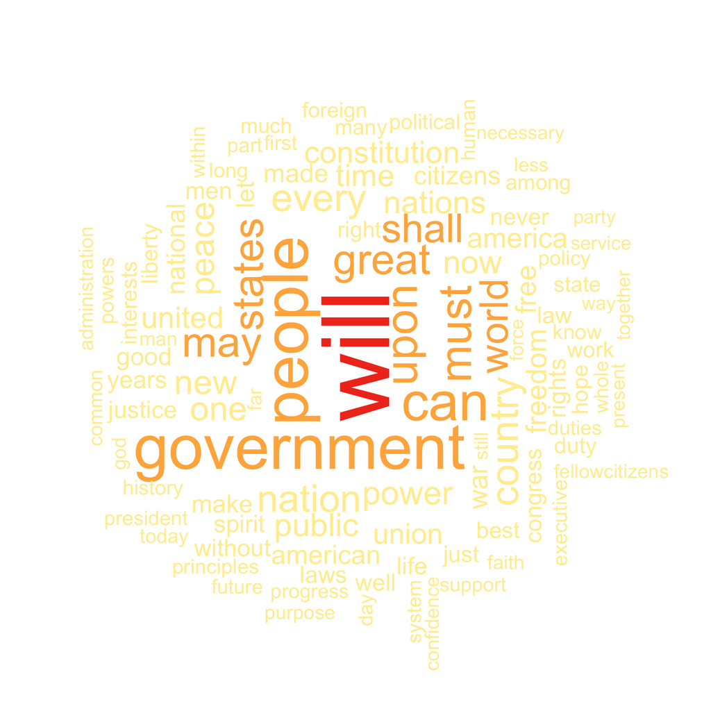

```r
file  <-tm_map(file, content_transformer(tolower))
file  <-tm_map(file, stripWhitespace)
file  <-tm_map(file, removeWords, stopwords("english"))
file  <-tm_map(file, removeWords, character(0))
file  <-tm_map(file, removePunctuation)
tdm.all<-TermDocumentMatrix(file)
tdm.tidy=tidy(tdm.all)
tdm.overall=summarise(group_by(tdm.tidy, term), sum(count))
wordcloud(tdm.overall$term, tdm.overall$`sum(count)`,
          scale=c(8,1),
          max.words=100,
          min.freq=1,
          random.order=FALSE,
          rot.per=0.3,
          use.r.layout=T,
          random.color=FALSE,
          colors=brewer.pal(3,"YlOrRd"))
```

We can see that the most frequently used words in presidents’ inaugural speeches are “Government”, “states”, “people”, “world” and “will”, “shall”, “must”, “can”. Given that the inaugural speech represents the very begining of the president’s term of office and delivers to the whole nations, most presidents tended to reiterate and emphasize the core values related to the country and discussed the topics related to “government”, “states” and “people”. In addition, they expressed their determinations and willingness in solving the issues people were concerned about, by using the words like “will”, “shall” and “must”. The wordcloud reveals 100 words, most of which are the most frequently used words in public speeches.

Next, I’m interested in the concentration and emphasis of individual president’s speeches over different periods of the history and the connections with the significant historical events. I chose the five most representative prisidents, George Washington (1789-1797), Abraham Lincoln(1861–1865), Franklin D. Roosevelt(1933–1945), John F. Kennedy(1961–1963), George W. Bush(2001-2009) from the list and analyze their wordcloud seperately.

# Step 3 Individual presidnt’s WordCloud

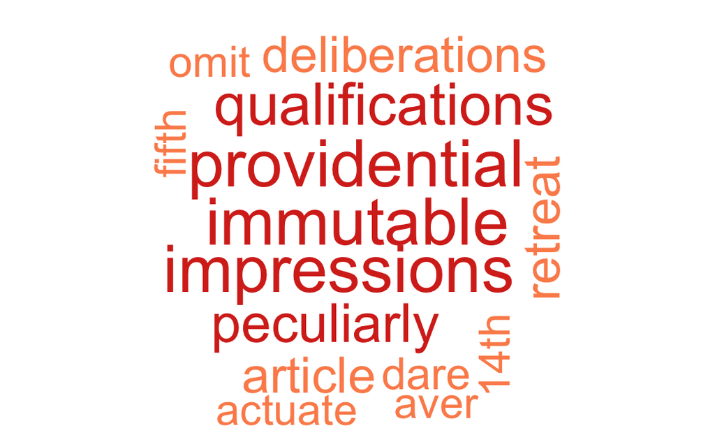

```r
file.1 <-Corpus(VectorSource(unlist(text.file)))
file.1 <-tm_map(file.1, stripWhitespace)
file.1 <-tm_map(file.1, content_transformer(tolower))
file.1 <-tm_map(file.1, removeWords, stopwords("english"))
file.1 <-tm_map(file.1, removeWords, character(0))
file.1 <-tm_map(file.1, removePunctuation)
dtm.1  <-DocumentTermMatrix(file.1,
                            control = list(weighting =function(x)
                              weightTfIdf(x, normalize =FALSE),
                              stopwords = TRUE))
ff.dtm.1 <- tidy(dtm.1)
### President George Washington
wordcloud(ff.dtm.1$term[ff.dtm.1$document==1],ff.dtm.1$count[ff.dtm.1$document==1],
          scale=c(3 ,0.4), min.freq=1, max.words= 80,
          random.order=FALSE, random.color = FALSE,
          rot.per=0.2, colors=brewer.pal(4, "OrRd"))
```

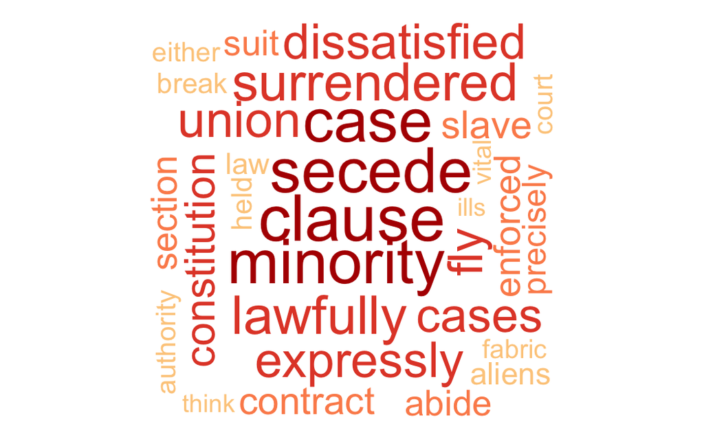

```r
### President Abraham Lincoln
wordcloud(ff.dtm.1$term[ff.dtm.1$document==19],ff.dtm.1$count[ff.dtm.1$document==19],
          scale=c(3 ,0.4), min.freq=1, max.words= 80,
          random.order=FALSE, random.color = FALSE,
          rot.per=0.2, colors=brewer.pal(5, "OrRd"))
```

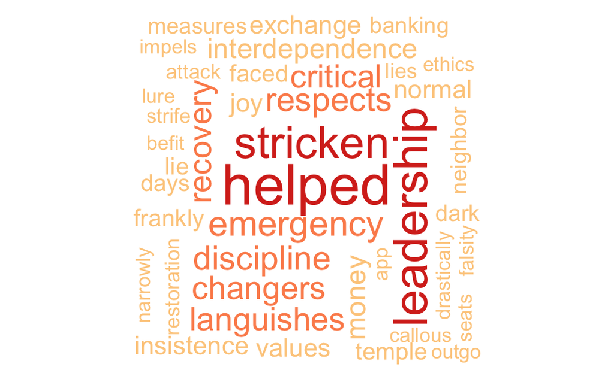

```r
### President Franklin D. Roosevelt
wordcloud(ff.dtm.1$term[ff.dtm.1$document==37&38&39&40],
          ff.dtm.1$count[ff.dtm.1$document==37&38&39&40],
          scale=c(3 ,0.4),min.freq=1, max.words= 100,
          random.order=FALSE, random.color = FALSE,
          rot.per=0.2, colors=brewer.pal(4, "OrRd"))
```

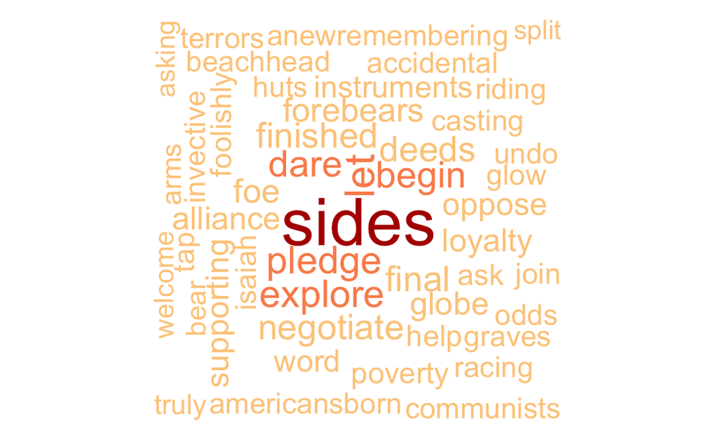

```r
### President John F. Kennedy
wordcloud(ff.dtm.1$term[ff.dtm.1$document==44],ff.dtm.1$count[ff.dtm.1$document==44],
          scale=c(3 ,0.7), min.freq=1, max.words= 80,
          random.order=FALSE, random.color = FALSE,
          rot.per=0.2, colors=brewer.pal(5, "OrRd"))
```